# Project - Unsupervised Learning

#### Preparation of the dataset for modelling.

```python
#get the list of columns.
scaled_df.columns
```

```
Index(['Avg_Credit_Limit', 'Total_Credit_Cards', 'Total_calls_made',
       'Total_visits_bank', 'Total_visits_online', 'Avg_Credit_limit_bin',
       'Total_visits_online_bin'],
      dtype='object')
```

```python
#final modeling dataset - remove the avg_credit_limit and the total_visits_online columns.
df_model = scaled_df[['Total_Credit_Cards', 'Total_calls_made',
       'Total_visits_bank','Avg_Credit_limit_bin', 'Total_visits_online_bin']].copy()
```

```python
#rename the binned columns to original columns name.
df_model.rename(columns = {'Avg_Credit_limit_bin':'Avg_Credit_limit', 'Total_visits_online_bin': 'Total_visits_online'},
               inplace = True)
```

#### K Means

Table of Contents

```
Silhoutte_score for clusters 2 = 0.7173003861381195
Silhoutte_score for clusters 3 = 0.45334623302698474
Silhoutte_score for clusters 4 = 0.4639877276600595
Silhoutte_score for clusters 5 = 0.46148156069568796
Silhoutte_score for clusters 6 = 0.42334316300473984
Silhoutte_score for clusters 7 = 0.31612691562548384
Silhoutte_score for clusters 8 = 0.30748644302166867
Silhoutte_score for clusters 9 = 0.2293994355689523
```

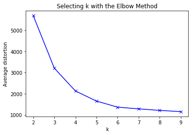

```python
#we range the clusters from 2 to 10
clusters=range(2,10)
#average distances between the points on the cluster to itself and the others.
meanDistortions=[]

for k in clusters:
    model=KMeans(n_clusters=k)
    model.fit(df_model)
    prediction=model.predict(df_model)
    sc = silhouette_score(df_model, prediction)
    print("Silhoutte_score for clusters {} = {}".format(k, sc))
    meanDistortions.append(model.inertia_)


plt.plot(clusters, meanDistortions, 'bx-')
plt.xlabel('k')
plt.ylabel('Average distortion')
plt.title('Selecting k with the Elbow Method')
```

#### Selection of Clusters and Initial Observations

Table of Contents

```python
#create a copy of the dataset for modelling.
df_model_k_means = df_model.copy()
#create a copy fo the original dataframe
wdf_k_means = wdf.copy()

final_model=KMeans(4)
final_model.fit(df_model_k_means)
prediction=final_model.predict(df_model_k_means)
print(silhouette_score(df_model_k_means, prediction))




#Append the prediction to copy of original dataframe
wdf_k_means["GROUP"] = prediction
print("Average based on groups assigned : \n")
wdf_k_means.head()
wdf_k_means.groupby(['GROUP']).mean()
```

```
0.4639877276600595
Average based on groups assigned :
```

| GROUP | Customer Key | Avg_Credit_Limit | Total_Credit_Cards | Total_visits_bank | Total_visits_online | Total_calls_made |
| --- | --- | --- | --- | --- | --- | --- |
| 0 | 55244.099099 | 12184.684685 | 2.400901 | 0.932432 | 3.572072 | 6.909910 |
| 1 | 57833.848168 | 53638.743455 | 5.575916 | 3.361257 | 0.984293 | 2.031414 |
| 2 | 57451.040816 | 142061.224490 | 8.755102 | 0.591837 | 11.000000 | 1.081633 |
| 3 | 51857.560606 | 14686.868687 | 5.449495 | 3.575758 | 1.010101 | 1.969697 |

```
array([[<matplotlib.axes._subplots.AxesSubplot object at 0x0000029CADA91630>,
      dtype=object)
```

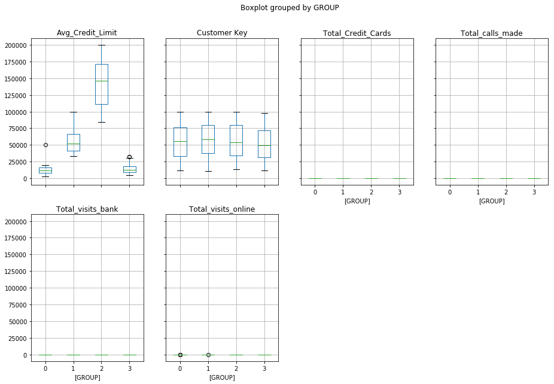

```python
#check the variation within each group using box plot
wdf_k_means.boxplot(by='GROUP', layout = (2,4),figsize=(15,10))
```

#### Obseration on KMeans Clustering

Table of Contents

1. There are 4 segmentation of the customers.
2. Segment 1 :
   - Least credit limit
   - Holds least amount of credit cards
   - Does not visit bank often
   - Has second highest number of visits online.
   - Has the most number of calls made.

   Segment 2 :
   - Second highest Credit limit
   - Second highest number of credit cards held
   - Visits bank often
   - Does not visit online
   - Second highest number of calls made.

   Segment 3 :
   - Highest Credit limit
   - Maximum amount of credit cards
   - Very less bank visit
   - Highest online visit
   - least amount of calls made.

   Segment 4 :
   - Third Highest Credit limit
   - Third Maximum amount of credit cards
   - Highest bank visit

#### Recommendations based on KMeans Clustering

Table of Contents

1. The highest credit holding customers are tech savvy, we must improve in our online support experience.
2. The second highest credit holding customers visit bank and make calls for support. We must provide them with best instore experience.
3. The customers who make the highest number of calls should be encouraged to use the online support experience. They could also be targetted for selling more credit cards through online experience.

#### Hierarchical Clustering

Table of Contents

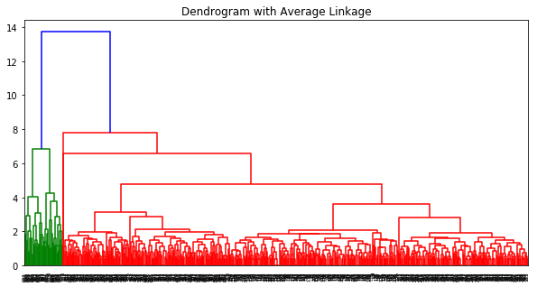

```python
#we draw dendrogram for different linkages , namely : average, complete and ward
plt.figure(figsize=(10,5))
ax = plt.axes()
dendrogram = sch.dendrogram(sch.linkage(df_model, method='average'))
ax.set_title('Dendrogram with Average Linkage')
```

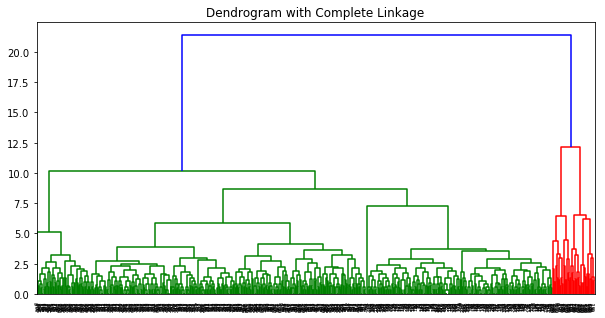

```python
plt.figure(figsize=(10,5))
ax = plt.axes()
dendrogram = sch.dendrogram(sch.linkage(df_model, method='complete'))
ax.set_title('Dendrogram with Complete Linkage')
```

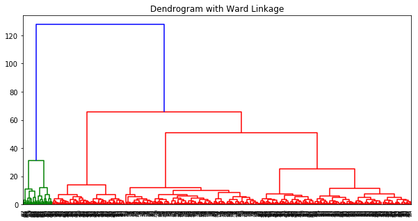

```python
plt.figure(figsize=(10,5))
ax = plt.axes()
dendrogram = sch.dendrogram(sch.linkage(df_model, method='ward'))
ax.set_title('Dendrogram with Ward Linkage')
```

#### Observations based on dendrogram

Table of Contents

```python
#we will not calculate the coefficient as follows
```

```python
clusters=range(3,6)
meanDistortions1=[]

#create a copy of the df_model :
df_model_dendro = df_model.copy()

print("for average linkage")
for k in clusters:
    aggmodel = AgglomerativeClustering(n_clusters=k, affinity='euclidean',  linkage='average')
    prediction = aggmodel.fit_predict(df_model_dendro)
    sc = silhouette_score(df_model_dendro, prediction)
    print("Silhoutte_score for clusters {} = {}".format(k, sc))

print("----------------------------------------------------------------")
print("for complete linkage")
for k in clusters:
    aggmodel = AgglomerativeClustering(n_clusters=k, affinity='euclidean',  linkage='complete')
    prediction = aggmodel.fit_predict(df_model_dendro)
    sc = silhouette_score(df_model_dendro, prediction)
    print("Silhoutte_score for clusters {} = {}".format(k, sc))

print("----------------------------------------------------------------")
print("for ward linkage")
for k in clusters:
    aggmodel = AgglomerativeClustering(n_clusters=k, affinity='euclidean',  linkage='ward')
    prediction = aggmodel.fit_predict(df_model_dendro)
    sc = silhouette_score(df_model_dendro, prediction)
    print("Silhoutte_score for clusters {} = {}".format(k, sc))
```

```
for average linkage
Silhoutte_score for clusters 3 = 0.472221683266928
Silhoutte_score for clusters 4 = 0.4754918343279064
Silhoutte_score for clusters 5 = 0.3679164578924486
----------------------------------------------------------------
for complete linkage
Silhoutte_score for clusters 3 = 0.6337611824126511
Silhoutte_score for clusters 4 = 0.39130166184933673
Silhoutte_score for clusters 5 = 0.3751513645529757
----------------------------------------------------------------
for ward linkage
Silhoutte_score for clusters 3 = 0.43289012353595663
Silhoutte_score for clusters 4 = 0.4347011246548191
Silhoutte_score for clusters 5 = 0.43235504236979705
```

#### Observations on Coefficients for Agglomerative Clustering

Table of Contents

```python
#create a copy of the wdf :
wdf_hierarchy = wdf.copy()

#let us now apply agglomorative method for cluster 4.
model = AgglomerativeClustering(n_clusters=4, affinity='euclidean',  linkage='average')
model.fit(df_model_dendro)
wdf_hierarchy['GROUP'] = model.labels_

print(silhouette_score(df_model_dendro, prediction))
#df_model_clust = df_model_dendro.groupby(['labels'])
#df_model_clust.mean()
```

```
0.43235504236979705
```

```python
print("Average based on groups assigned : \n")
wdf_hierarchy.head()
wdf_hierarchy.groupby(['GROUP']).mean()
```

```
Average based on groups assigned :
```

| GROUP | Customer Key | Avg_Credit_Limit | Total_Credit_Cards | Total_visits_bank | Total_visits_online | Total_calls_made |
| --- | --- | --- | --- | --- | --- | --- |
| 0 | 54960.331691 | 25725.779967 | 4.379310 | 2.553366 | 1.927750 | 3.794745 |
| 1 | 55487.375000 | 109625.000000 | 8.875000 | 0.625000 | 11.000000 | 1.208333 |
| 2 | 87073.000000 | 100000.000000 | 2.000000 | 1.000000 | 1.000000 | 0.000000 |
| 3 | 57836.192308 | 170038.461538 | 8.615385 | 0.576923 | 10.807692 | 0.961538 |

```
array([[<matplotlib.axes._subplots.AxesSubplot object at 0x0000029CB2442208>,
      dtype=object)
```

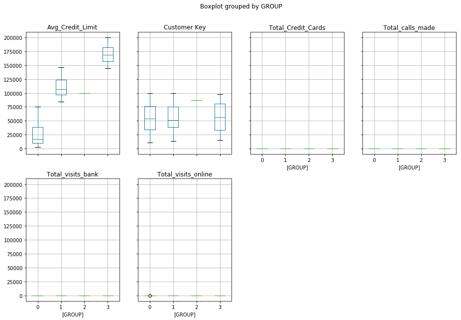

```python
#check the variation within each group using box plot
wdf_hierarchy.boxplot(by='GROUP', layout = (2,4),figsize=(15,10))
```

#### Obseration on Hierarchical Clustering

Table of Contents

1. There are 4 segmentation of the customers.
2. Segment 1 :
   - Least credit limit
   - Has highest visit to the bank.
   - Has the most number of calls.

   Segment 2 :
   - Second highest Credit limit
   - Highest number of credit cards held
   - Highest Visits online.

   Segment 4 :
   - Highest Credit limit
   - SecondMaximum amount of credit cards
   - second Highest online visit.

#### Recommendations based on Hierarchical Clustering

Table of Contents

1. The highest credit holding customers are tech savvy, we must improve in our online support experience.
2. The customers who make the highest number of calls should be encouraged to use the online support experience. They could also be targetted for selling more credit cards through online experience.

```python
print("Average based on groups assigned for K Means: \n")
wdf_k_means.head()
wdf_k_means.groupby(['GROUP']).mean()
```

```
Average based on groups assigned for K Means:
```

| GROUP | Customer Key | Avg_Credit_Limit | Total_Credit_Cards | Total_visits_bank | Total_visits_online | Total_calls_made |
| --- | --- | --- | --- | --- | --- | --- |
| 0 | 55244.099099 | 12184.684685 | 2.400901 | 0.932432 | 3.572072 | 6.909910 |
| 1 | 57833.848168 | 53638.743455 | 5.575916 | 3.361257 | 0.984293 | 2.031414 |
| 2 | 57451.040816 | 142061.224490 | 8.755102 | 0.591837 | 11.000000 | 1.081633 |
| 3 | 51857.560606 | 14686.868687 | 5.449495 | 3.575758 | 1.010101 | 1.969697 |

```python
print("---------------------------------------------------")
print("Average based on groups assigned for Hierarchical Clustering: \n")
wdf_hierarchy.head()
wdf_hierarchy.groupby(['GROUP']).mean()
```

```
---------------------------------------------------
Average based on groups assigned for Hierarchical Clustering:
```

| GROUP | Customer Key | Avg_Credit_Limit | Total_Credit_Cards | Total_visits_bank | Total_visits_online | Total_calls_made |
| --- | --- | --- | --- | --- | --- | --- |
| 0 | 54960.331691 | 25725.779967 | 4.379310 | 2.553366 | 1.927750 | 3.794745 |
| 1 | 55487.375000 | 109625.000000 | 8.875000 | 0.625000 | 11.000000 | 1.208333 |
| 2 | 87073.000000 | 100000.000000 | 2.000000 | 1.000000 | 1.000000 | 0.000000 |
| 3 | 57836.192308 | 170038.461538 | 8.615385 | 0.576923 | 10.807692 | 0.961538 |

#### Comparison Between Clusters

Table of Contents

[output not shown]